# Métodos Computacionais II

2018/2

[Jony Arrais Pinto Junior](http://lattes.cnpq.br/4940428746026448)

## 1 - Conteúdo Aula 05

- Medidas descritivas;
- Tabelas de distribuição de frequência;
- ggplot2.

## 2 - Leitura da base de dados

Inicialmente vamos fazer a importação da base **Base saude** (base).

Lembrem-se:

1 - Verifiquem se o diretório que o R está “enxergando” é o mesmo no qual o arquivo que você deseja importar se encontra; se não for, modifique-o;

2 - Verifique qual a extensão do arquivo que desejamos importar, para saber qual a função iremos utilizar.

3 - 9 significa valores faltantes na codificação da base.

```
## Using ',' as decimal and '.' as grouping mark. Use read_delim() for more control.
```

```r
#Visualizando a base de dados
base
```

```
## # A tibble: 200 x 10
##    Codigo Datacol   Sexo Idade  Peso Estatura   HIV Escol   DST  Tipo
##    <chr>  <chr>    <int> <int> <dbl>    <dbl> <int> <int> <int> <int>
##  1 AB01   14/10/15     1    15  65.4     1.62     1     3     1     2
##  2 AB02   09/02/16     0    28  60.4     1.55     0     5     0    NA
##  3 AB03   01/03/10     0    15  87.6     1.89     1     2     1     3
##  4 AB04   04/05/13     0    13  86.3     1.94     1    NA     1     2
##  5 AB05   20/05/14     0    19  81.2     1.65     0     2     1     3
##  6 AB06   30/01/11     1    14  77.2     1.66     1     6     0    NA
##  7 AB07   05/08/15     1    25  63.4     1.59     1     5     1     3
##  8 AB08   08/12/13     1    26  73.2     1.59     0     1     0     2
##  9 AB09   03/11/10     1    35  63.1     1.64     1     4     1     1
## 10 AB10   10/10/10     1    37  58.7     1.56     1     5     1    NA
## # ... with 190 more rows
```

Fazendo o tratamento da base de dados

```r
#Transformando a variável Sexo em um factor
base$Sexo = factor(base$Sexo, labels=c("Feminino","Masculino"))

#Transformando a variável HIV em um factor
base$HIV = factor(base$HIV, labels=c("Não","Sim"))

#Transformando a variável Escolaridade em um ordered
base$Escol = ordered(base$Escol,levels=c(0,1,2,3,4,5), labels=c("Analfabeto","Fundamental Incompleto","Fundamental Completo","Medio Incompleto", "Medio Completo","Superior"))

#Transformando a variável DST em um factor
base$DST = factor(base$DST, labels=c("Não","Sim"))

#Transformando a variável Tipo de DST em um factor
base$Tipo = factor(base$Tipo, labels=c("Sifilis","Hepatite","Outros"))

#Visualizando a base
head(base)
```

```
## # A tibble: 6 x 10
##   Codigo Datacol  Sexo      Idade  Peso Estatura HIV   Escol   DST   Tipo
##   <chr>  <chr>    <fct>     <int> <dbl>    <dbl> <fct> <ord>   <fct> <fct>
## 1 AB01   14/10/15 Masculino    15  65.4     1.62 Sim   Medio … Sim   Hepa…
## 2 AB02   09/02/16 Feminino     28  60.4     1.55 Não   Superi… Não   <NA>
## 3 AB03   01/03/10 Feminino     15  87.6     1.89 Sim   Fundam… Sim   Outr…
## 4 AB04   04/05/13 Feminino     13  86.3     1.94 Sim   <NA>    Sim   Hepa…
## 5 AB05   20/05/14 Feminino     19  81.2     1.65 Não   Fundam… Sim   Outr…
## 6 AB06   30/01/11 Masculino    14  77.2     1.66 Sim   <NA>    Não   <NA>
```

## 3 - Medidas descritivas

Algumas medidas descritivas de interesse para variáveis quantitativas:

```r
#Média
mean(base$Idade)
```

```
## [1] 24.15
```

```r
#Mediana
median(base$Estatura)
```

```
## [1] NA
```

```r
median(base$Estatura, na.rm=TRUE)
```

```
## [1] 1.65
```

```r
#Quantis
quantile(base$Peso, c(.1,.25,.5,.6,.9))
```

```
##    10%    25%    50%    60%    90%
## 61.790 66.040 71.680 74.580 83.756
```

```r
#Variância
var(base$Idade)
```

```
## [1] 49.80653
```

```r
#Desvio padrão
sd(base$Estatura, na.rm=TRUE)
```

```
## [1] 0.1137331
```

```r
#Carregando o pacote dplyr
library(dplyr)

#Calculando uma mesma função para diversas variáveis
aux = base %>% select(Idade,Peso)
apply(aux,2,sum)
```

```
##    Idade     Peso
##  4830.00 14433.69
```

```r
apply(aux,2,mean)
```

```
##    Idade     Peso
## 24.15000 72.16845
```

```r
apply(aux,1,median)
```

```
##   [1] 40.180 44.220 51.320 49.635 50.100 45.615 44.190 49.575 49.040 47.840
##  [11] 45.975 60.720 50.265 56.580 43.075 45.820 45.930 58.310 53.040 50.365
##  [21] 46.595 45.000 44.850 49.585 48.240 42.000 42.285 45.550 49.725 46.310
##  [31] 46.265 53.285 56.275 47.770 46.135 50.540 47.640 60.925 49.745 48.145
##  [41] 50.235 56.715 43.530 43.680 48.985 51.540 52.600 47.700 40.955 43.150
##  [51] 45.405 45.715 43.560 40.155 49.950 51.495 45.600 44.790 50.915 46.115
##  [61] 41.810 48.160 53.830 61.205 53.010 51.585 51.680 55.590 44.390 45.395
##  [71] 45.700 51.255 49.015 47.785 43.915 41.970 46.590 51.250 44.965 47.225
##  [81] 55.730 44.895 44.205 45.705 49.055 54.690 48.595 57.225 46.945 56.995
##  [91] 61.865 47.560 45.450 39.855 48.795 49.240 48.540 44.685 55.980 39.545
## [101] 49.425 45.755 44.180 41.640 49.480 43.680 43.465 46.065 53.010 46.580
## [111] 45.290 50.125 46.140 52.775 48.805 54.040 41.700 54.620 48.060 50.790
## [121] 53.825 44.975 45.275 42.180 46.530 44.260 51.290 47.830 50.025 51.470
## [131] 46.220 46.460 46.600 40.110 46.150 44.465 45.695 42.580 48.795 50.815
## [141] 43.180 47.220 52.260 52.905 50.245 55.835 46.640 49.255 51.195 48.820
## [151] 50.690 43.815 41.780 44.620 53.380 47.975 47.240 40.045 47.515 53.055
## [161] 48.060 35.125 52.600 49.705 50.865 51.375 48.155 46.855 50.870 45.365
## [171] 40.230 50.085 53.250 44.415 47.365 47.765 44.640 40.525 48.985 49.775
## [181] 46.410 48.110 53.685 49.140 55.265 50.070 55.350 46.550 54.890 43.195
## [191] 43.815 44.625 54.775 47.770 48.260 53.650 41.285 39.595 45.605 51.615
```

### 3.1 - Tabelas de distribuição de frequências para variáveis qualitativas:

```r
#Tabela simples
table(base$Escol)
```

```
##
##             Analfabeto Fundamental Incompleto   Fundamental Completo
##                     13                     32                     34
##       Medio Incompleto         Medio Completo               Superior
##                     13                     30                     26
```

```r
#Obtendo os percentuais
prop.table(table(base$Escol))
```

```
##
##             Analfabeto Fundamental Incompleto   Fundamental Completo
##             0.08783784             0.21621622             0.22972973
##       Medio Incompleto         Medio Completo               Superior
##             0.08783784             0.20270270             0.17567568
```

```r
#Tabela de contingência
table(base$Escol,base$HIV)
```

```
##
##                          Não Sim
##   Analfabeto               0  13
##   Fundamental Incompleto  14  18
##   Fundamental Completo    21  13
##   Medio Incompleto         1  12
##   Medio Completo          13  16
##   Superior                13  13
```

```r
#Obtendo os percentuais
prop.table(table(base$Escol,base$HIV),1)
```

```
##
##                                 Não        Sim
##   Analfabeto             0.00000000 1.00000000
##   Fundamental Incompleto 0.43750000 0.56250000
##   Fundamental Completo   0.61764706 0.38235294
##   Medio Incompleto       0.07692308 0.92307692
##   Medio Completo         0.44827586 0.55172414
##   Superior               0.50000000 0.50000000
```

```r
prop.table(table(base$Escol,base$HIV),2)
```

```
##
##                                 Não        Sim
##   Analfabeto             0.00000000 0.15294118
##   Fundamental Incompleto 0.22580645 0.21176471
##   Fundamental Completo   0.33870968 0.15294118
##   Medio Incompleto       0.01612903 0.14117647
##   Medio Completo         0.20967742 0.18823529
##   Superior               0.20967742 0.15294118
```

```r
#Carregando o pacote dplyr
library(sjPlot)

#Tabela de distribuição de frequências
sjt.frq(base$Escol, show.summary = FALSE, title= "Escolaridade")
```

Escolaridade

| value | N | raw % | valid % | cumulative % |
| --- | --- | --- | --- | --- |
| Analfabeto | 13 | 6.50 | 8.78 | 8.78 |
| Fundamental Incompleto | 32 | 16.00 | 21.62 | 30.41 |
| Fundamental Completo | 34 | 17.00 | 22.97 | 53.38 |
| Medio Incompleto | 13 | 6.50 | 8.78 | 62.16 |
| Medio Completo | 30 | 15.00 | 20.27 | 82.43 |
| Superior | 26 | 13.00 | 17.57 | 100.00 |
| missings | 52 | 26.00 |  |  |

```r
#Tabela de contingência
sjt.xtab(base$Escol,base$HIV, var.labels = c("Escolaridade","Soropositivo"), show.col.prc = TRUE, show.summary = FALSE)
```

| Escolaridade | Soropositivo |  | Total |  |
| --- | --- | --- | --- | --- |
|  | Não | Sim |  |  |
| Analfabeto | 0 0 % | 13 15.3 % |  | 13 8.8 % |
| Fundamental Incompleto | 14 22.6 % | 18 21.2 % | 32 21.8 % |  |
| Fundamental Completo | 21 33.9 % | 13 15.3 % | 34 23.1 % |  |
| Medio Incompleto | 1 1.6 % | 12 14.1 % | 13 8.8 % |  |
| Medio Completo | 13 21 % | 16 18.8 % | 29 19.7 % |  |
| Superior | 13 21 % | 13 15.3 % | 26 17.7 % |  |
| Total | 62 100 % | 85 100 % | 147 100 % |  |

Se desejar obter as porcentagens por linhas ou por células basta usar os argumentos show.row.prc e show.cell.prc.

## 4 - O pacote ggplot2

### Porque ggplot2?

Vantagens de ggplot2

- Gramática de gráficos consistente;
- especificação de plotagem em um alto nível de abstração;
- muito flexível;
- Sistema de tema para polir a aparência do gráfico;
- sistema gráfico completo e maduro;
- muitos usuários, lista de discussão ativa.

Dito isto, existem algumas coisas que você não pode (ou não deve) fazer com o ggplot2:

- Gráficos tridimensionais (veja o pacote RGL);
- Gráficos de tipos de teoria de grafos (veja o pacote igraph);
- Gráficos interativos (veja o pacote ggvis).

Qual é **gramática dos gráficos**?

Idéia básica: especificar separadamente blocos de construção de plotagem e combiná-los para criar qualquer tipo de exibição gráfica que você deseja.

Os blocos de construção de um gráfico incluem:

- dados;
- mapeamento estético;
- objeto geométrico;
- transformações estatísticas;
- escalas;
- sistema de coordenadas;
- ajustes de posição;
- facetas;

A estrutura básica de código para criar um **ggplot** é a seguinte:

**ggplot(meu_data_frame, aes(x, y)) + geom()**

Primeiro criamos um plot com a função **ggplot**. O primeiro argumento é **data**, onde você especifica o data frame com suas variáveis. Depois vem o **mapping**. Nele você cria o “*mapeamento*” das variáveis, normalmente usando **aes** (de aesthetics). Ou seja, você especifica quais são as variáveis dos eixos *x* e *y*, além de outras opções como **cores** e **símbolos** usados para plotar os dados.

Depois da função **ggplot**, nós especificamos um **geom**. Por exemplo, **geom_point** para plotar pontos, **geom_boxplot** para um boxplot, etc. Para a lista completa de geoms e todas as outras opções do pacote, visite a página do projeto [ggplot2](http://ggplot2.tidyverse.org/reference/index.html).

Note que adicionamos um **geom** com um “+”. No ggplot2, nós criamos gráficos em **camadas** (layers), e adicionamos camada a camada com um “+”.

## ggplot2 VS Gráficos básicos

Comparado ggplot2 com os gráficos usuais:

- é mais complicado para gráficos simples;
- é menos complicado para gráficos complexos:
- não tem métodos definidos (exemplo, os dados devem estar sempre em um formato data.frame);
- usa um sistema diferente para adicionar elementos ao gráfico.

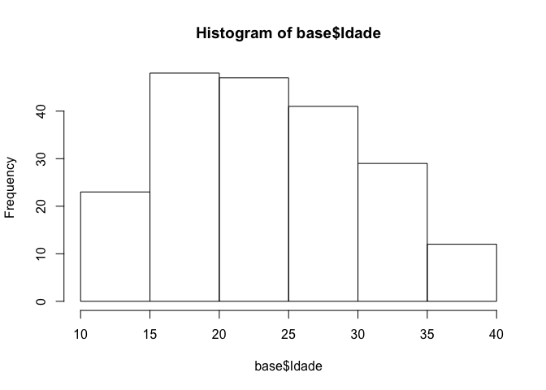

```r
library(ggplot2)

#Histograma da variável Idade usando os gráficos usuais
hist(base$Idade)
```

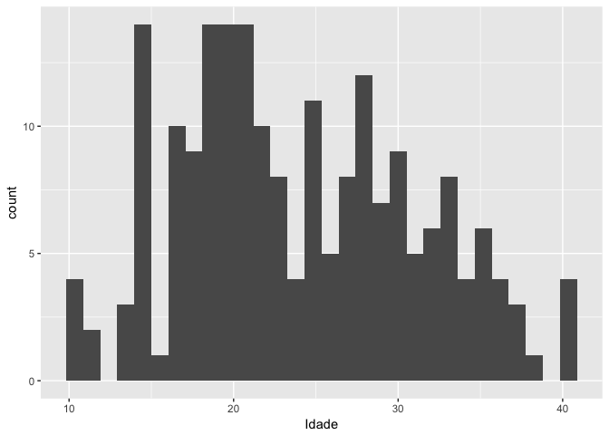

```r
#Histograma da variável Idade usando ggplot2
ggplot(base, aes(x = Idade)) + geom_histogram()
```

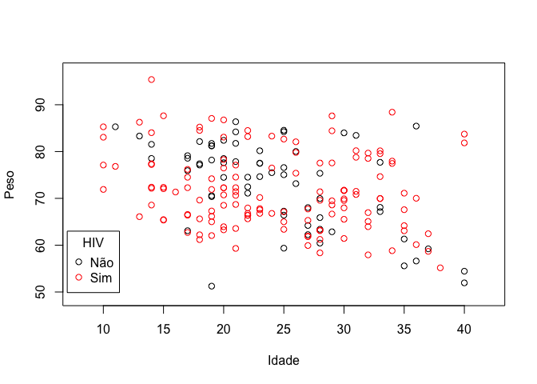

```r
# Gráfico mais complicado usando as ferramentas básicas
plot(Peso ~ Idade, data=subset(base, HIV == "Não"),ylim=c(49,97),xlim=c(8,42))
points(Peso ~ Idade, col="red", data=subset(base, HIV == "Sim"))
legend(7, 63,
       c("Não", "Sim"), title="HIV",
       col=c("black", "red"),
       pch=c(1, 1))
```

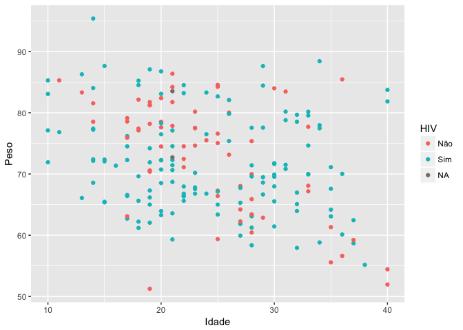

```r
# Gráfico mais complicado usando ggplot2
ggplot(base, aes(x=Idade, y=Peso, color=HIV)) + geom_point()
```

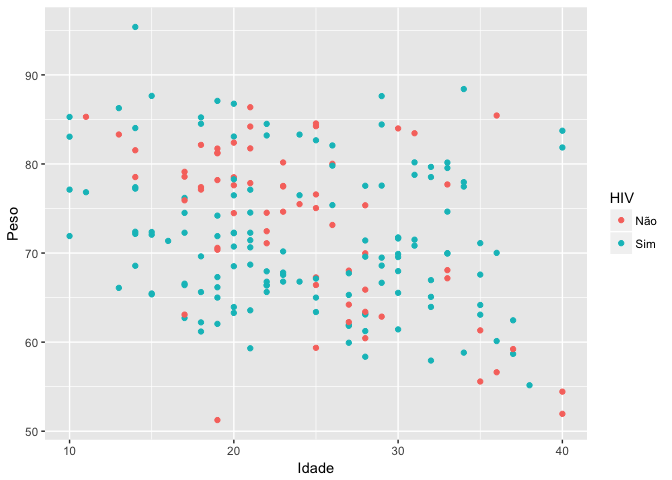

```r
base %>% filter(!is.na(HIV)) %>% ggplot(aes(x=Idade, y=Peso, color=HIV)) + geom_point()
```

## 4.1 - Scaterplot (diagrama de dispersão)

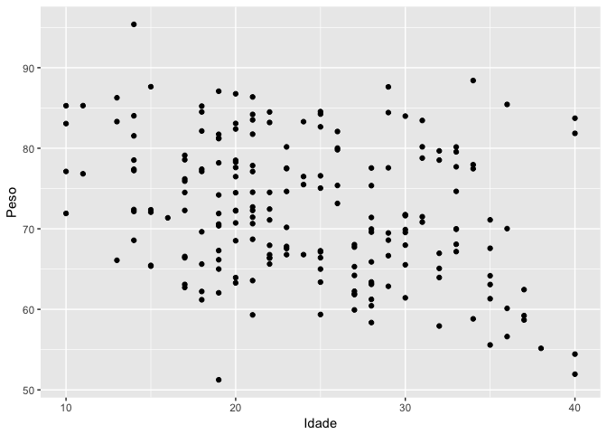

```r
#Diagrama de dispersão
graf1 = ggplot(base, aes(x=Idade, y=Peso)) + geom_point()

#Visualizando o gráfico de dispersão
graf1
```

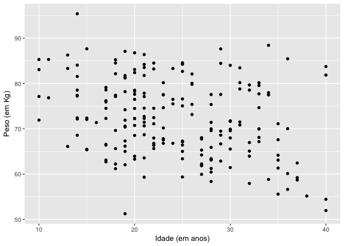

```r
#Acrescentando no gráfico os rótulos dos eixos x e y
graf1 + xlab("Idade (em anos)") + ylab("Peso (em Kg)")
```

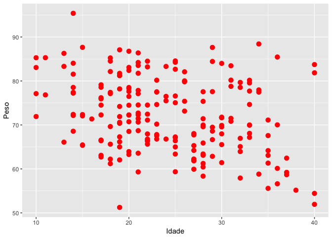

```r
# Modificando cor e tamanho dos pontos
graf1 + geom_point(colour = "red", size = 3)
```

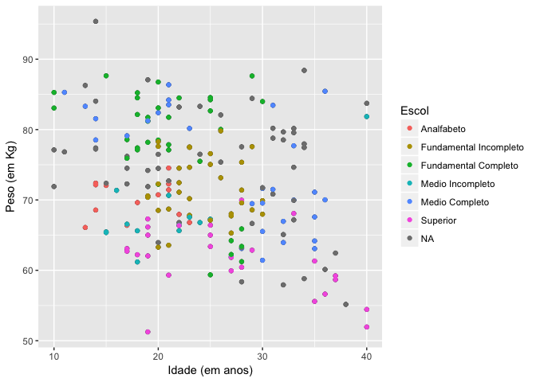

```r
#Gráfico de dispersão indicando as categorias de escolaridade por diferentes cores
graf1 + geom_point(aes(colour = Escol)) + xlab("Idade (em anos)") +
ylab("Peso (em Kg)")
```

Exercício:

Crie um gráfico de dispersão de Idade e Peso considerando somente indivíduos HIV positivo e com DST. **Não esqueça de usar o %>%**

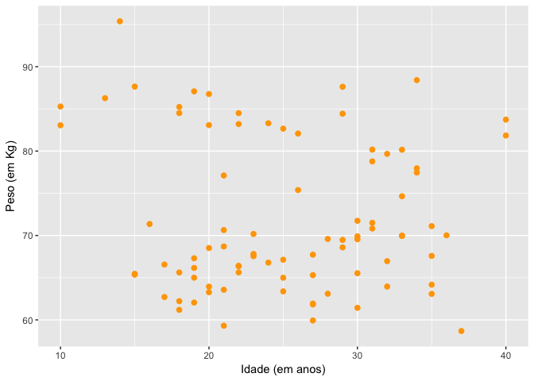

### 4.2 - Gráfico de barras/colunas

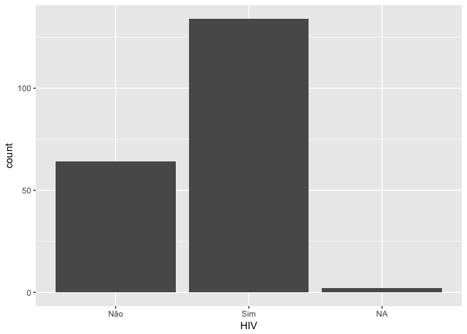

```r
#Carregando o pacote ggplot2
library(ggplot2)

#Gráfico de barras
graf2 = ggplot(base, aes(x=HIV)) + geom_bar()

#Visualizando o gráfico de barras
graf2
```

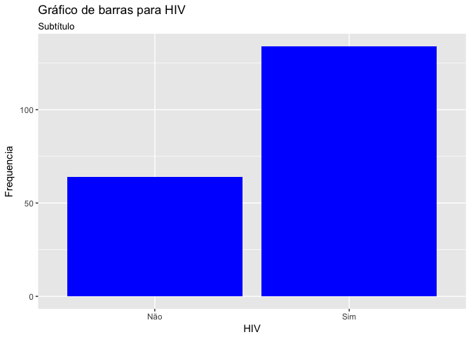

```r
#Retirando os NAs, modificando a cor e acrescentando título e subtítulo
graf2 = base %>% filter(!is.na(HIV)) %>% ggplot(aes(x=HIV)) + geom_bar(fill="blue") + ylab("Frequencia") + ggtitle("Gráfico de barras para HIV","Subtítulo")

graf2
```

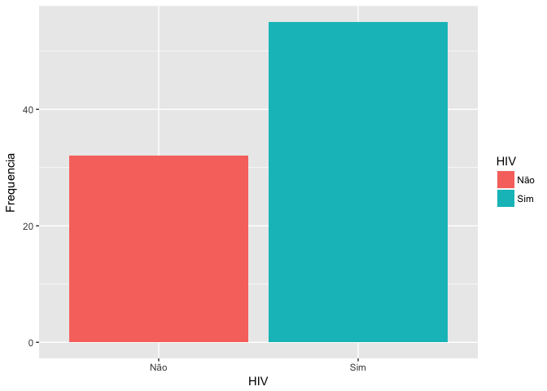

```r
#Acrescentando uma cor para cada barra
ggplot(na.omit(base), aes(x=HIV)) + geom_bar(aes(fill=HIV)) + ylab("Frequencia")
```

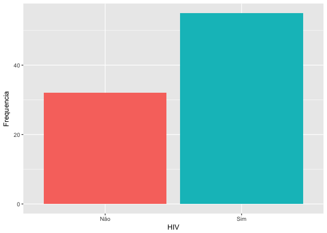

```r
#Retirando a legenda desnecessária
ggplot(na.omit(base), aes(x=HIV)) + geom_bar(aes(fill=HIV)) + ylab("Frequencia") + guides(fill=FALSE)
```

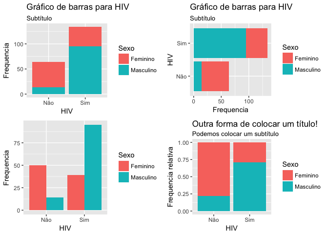

```r
#Acrescentando o sexo no gráfico de 3 maneiras distintas
graf2.1 = graf2 + geom_bar(aes(fill=Sexo)) + ylab("Frequencia")

graf2.2 = graf2 + geom_bar(aes(fill=Sexo)) + ylab("Frequencia") + coord_flip()

graf2.3 = base %>% filter(!is.na(HIV)) %>% ggplot(aes(x=HIV)) + geom_bar(aes(fill=Sexo), position = "dodge") + ylab("Frequencia")

graf2.4 = base %>% filter(!is.na(HIV)) %>% ggplot(aes(x=HIV)) + geom_bar(aes(fill=Sexo), position = "fill") + labs(title="Outra forma de colocar um título!", subtitle="Podemos colocar um subtítulo", y="Frequencia relativa")


#Carregando pacote para plotar mais de um gráfico numa mesma figura
library(gridExtra)

#Plotando o gráfico
grid.arrange(graf2.1, graf2.2, graf2.3, graf2.4, ncol=2, nrow=2)
```

### 4.2 - Histogramas

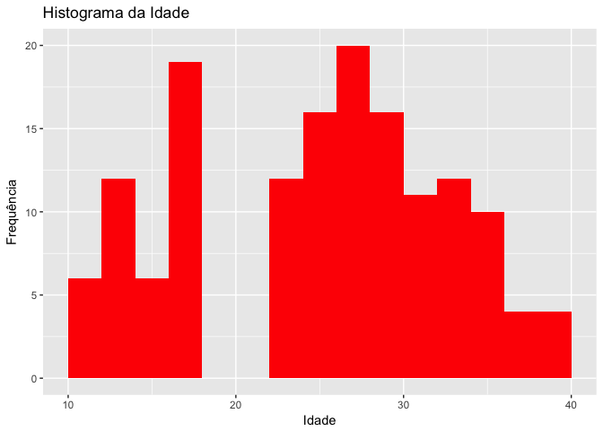

```r
library(ggplot2)

#Histograma da variável Idade usando ggplot2
ggplot(base, aes(x = Idade)) + geom_histogram(breaks=seq(10,40,by=2), fill="red") + labs(title = "Histograma da Idade") + xlab("Idade") + ylab("Frequência") + ylim(c(0,20))
```

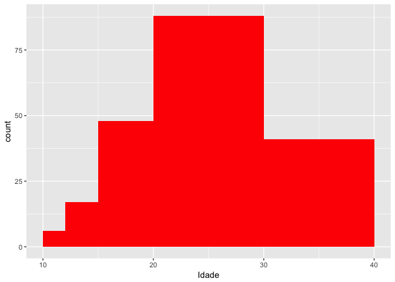

```r
ggplot(base, aes(x = Idade)) + geom_histogram(breaks=c(10,12,15,20,30,40), fill="red")
```

### 4.3 - Boxplot

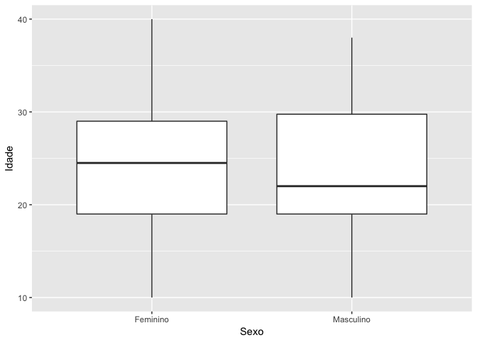

```r
#Carregando o pacote ggplot2
library(ggplot2)

#Boxplot
graf3 = ggplot(base, aes(x = Sexo, y = Idade)) + geom_boxplot()

#Visualizando o boxplot
graf3
```

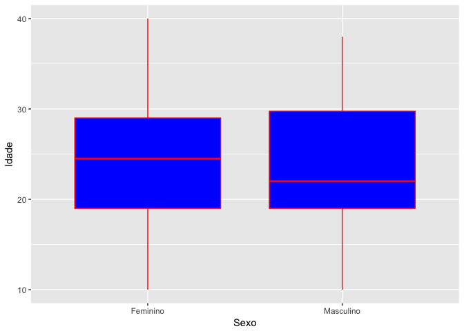

```r
#Colorindo as caixas
ggplot(base, aes(x = Sexo, y = Idade)) + geom_boxplot(color = "red",fill="blue")
```

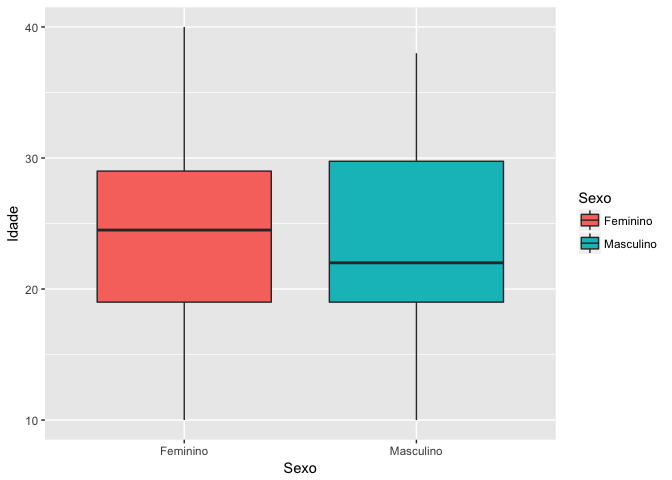

```r
#Acrescentando uma cor para cada caixa
ggplot(base, aes(x = Sexo, y = Idade, fill=Sexo)) + geom_boxplot()
```

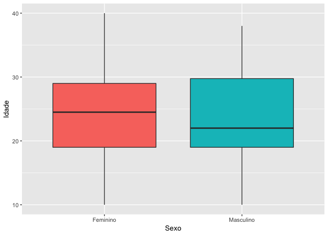

```r
#Retirando a legenda desnecessária
ggplot(base, aes(x = Sexo, y = Idade, fill=Sexo)) + geom_boxplot() + guides(fill=FALSE)
```

### 4.4 - Facet

Utilizado para dividir um gráfico pelas categorias de uma variável de interesse.

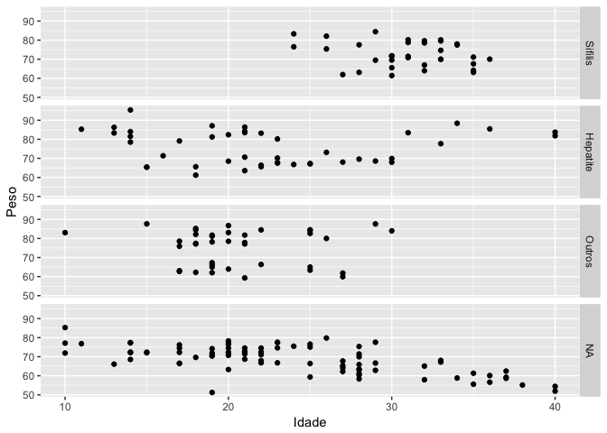

```r
#Carregando o pacote ggplot2
library(ggplot2)

#Dividindo o gráfico 1 por escolaridade
graf1 + facet_grid(Tipo ~ .)
```

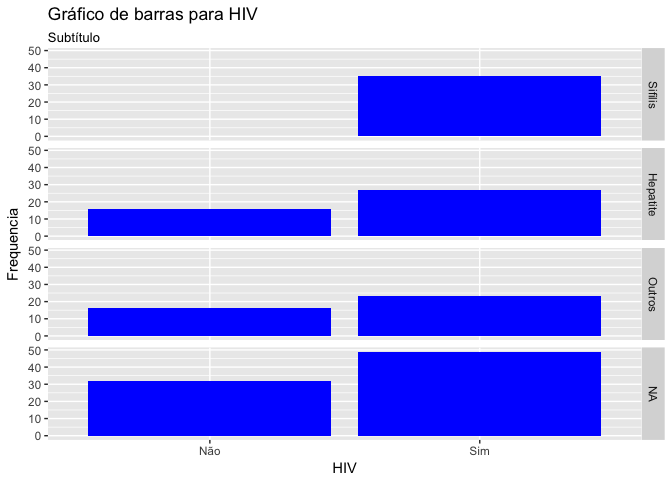

```r
#Particionando o gráfico 2 por escolaridade
graf2 + facet_grid(Tipo ~ .)
```

### 4.5 - Theme

Gerenciando temas (layouts) dos gráficos (características gerais), como rótulos dos eixos, títulos, o fundo do gráfico, os rótudos dos facets e aparência da legenda.

Exemplos de temas existentes:

theme_gray() (default) theme_bw() theme_linedraw() theme_light() theme_minimal() theme_classic() theme_void()

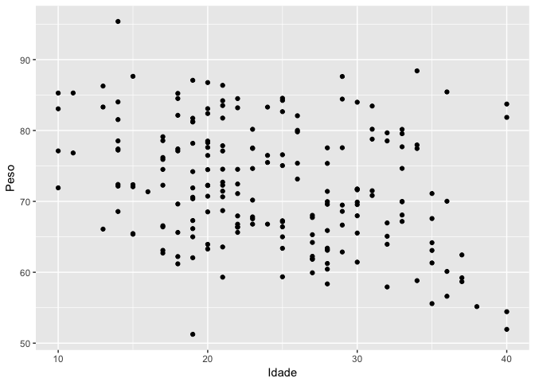

```r
#Visualizando o graf 1 no tema default
graf1
```

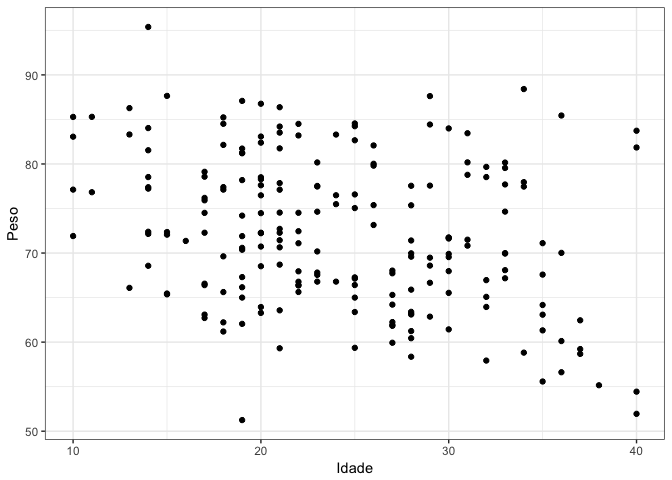

```r
#VModificando o tema do gráfico 1
graf1 + theme_bw()
```

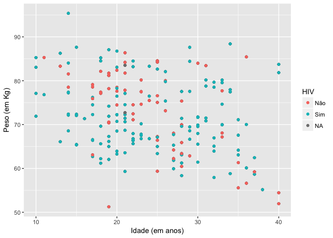

```r
#Criando o gráfico 5
graf5 = graf1 + geom_point(aes(colour = HIV)) + xlab("Idade (em anos)") + ylab("Peso (em Kg)")

graf5
```

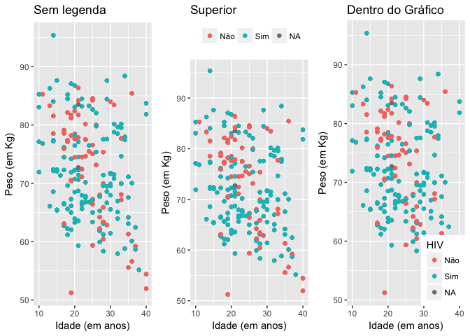

```r
#Modificando a posição da legenda do gráfico anterior
graf5.1 = graf5 + geom_point(aes(colour=HIV)) + theme(legend.position="none") + labs(title="Sem legenda")
graf5.2 = graf5 + geom_point(aes(colour=HIV)) + theme(legend.position="top", legend.direction="horizontal", legend.title = element_blank()) + labs(title="Superior")
graf5.3 = graf5 + geom_point(aes(colour=HIV)) + labs(title="Dentro do Gráfico") + theme(legend.justification=c(1,0), legend.position=c(1,0))

grid.arrange(graf5.1, graf5.2, graf5.3, ncol=3)
```